# Predicting student achievement

Raj Prasad June 2019

[html version](https://daddyprasad5.github.io/STAR_v3.html) - with all the code hidden away for a quick read

[jupyter notebook version](https://github.com/daddyprasad5/thinkful/blob/master/STAR_v3.ipynb) - with all the code exposed in an interactive notebook

[slides version](https://daddyprasad5.github.io/STAR_v3.slides.html) - presentation version

### Summary

The "STAR Project" tested the impact of class size on student achievement in kindergarten through third grade in Tennessee in the mid 1980s. I am going to use the same data to see how well I can predict student achievement based on the other variables available in the dataset.

#### Motivation

- Prediction of achievement can identify students that are at risk and who might merit additional intervention
- Identifying meaningful explanatory variables for student achievement might drive education practice or government policy

#### Findings:

My models were able to explain ~70% of the variance in 3rd grade achievement.

*Common predictors across the models:*

- prior years' standardized test scores
- school id
- teacher and student race

*Random Forest Predictors:*

- student demographics (age, race, gender)
- student economic status (free lunch)
- teacher quality (yrs of experience, highest degree earned)
- teacher race
- teacher/student race match
- school urbanicity
- class size

*Class Size & Matched Race*

Two of these have garnered special attention -class size and student/teacher race match.

At the end of this presentation, I've included some supporting analysis for both findings. For both reduced class size and student/teach race match, there are significant differences in grade 3 achievement.

# Deeper Review:

- Data preparation
- Target
- Predictors
- Model fit and feature selection
- Class size and Race Match

## Data Preparation

I pulled the data from the [Harvard dataverse](https://dataverse.harvard.edu/dataset.xhtml?persistentId=hdl:1902.1/10766). The preparation process included trimming the data to include the data relevant to third grade only, and dealing with a small number of missing values. There were no outliers that required attention.

```python
#reduce data set to include only students included in the third grade year, and only the variables of interest↔
```

```
The entire dataset has 11601 observations; The grade 3 data include 2034 observations
The entire dataset has 379 columns; The grade 3 dataset includes 42 columns
```

```python
#fill nulls↔
```

```
missing values before filling...
```

|  | Total | Percent | short_name |
| --- | --- | --- | --- |
| FREE/REDUCED LUNCH STATUS GRADE 3 | 62 | 0.030482 | g3freelunch |
| TEACHER HIGHEST DEGREE GRADE 3 | 20 | 0.009833 | g3thighdegree |
| TEACHER RACE/ETHNICITY GRADE 3 | 11 | 0.005408 | g3trace |
| YEARS OF TOTAL TEACHING EXPERIENCE GRADE 3 | 11 | 0.005408 | g3tyears |

```
missing values after filling...
```

|  | Total | Percent | short_name |
| --- | --- | --- | --- |

### Target Variable

- z-score of the sum of all the grade 3 standardized test scores
- 12 Stanford Achievement(SAT) Tests
- 2 Basic Skills First (BSF) Tests

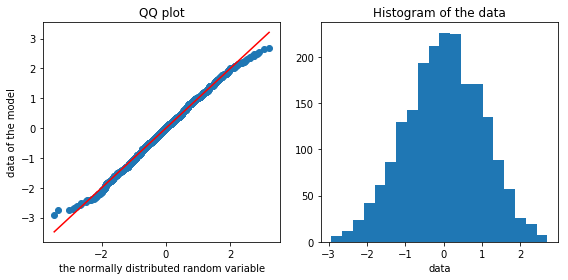

```
Jarque-Bera test statistics is 12.334422037663987 and p value is 0.0020970765591565854
Normality test statistics is 15.403927777273752 and p value is 0.0004519387534016881
```

```python
#calculate target variable, evaluate normality. ↔
```

### Initial Predictors

- student demographic & economic data: age, race, gender, free lunch recipient
- teacher demographic and quality: race, years teaching, highest degree achieved
- race-match: True if the student and teacher identify as the same race
- school data: school id number, urbanicity (urban, surburban, rural or inner-city)
- class size: small (13-17 students), regular (22-26), regular with aid

[output not shown]

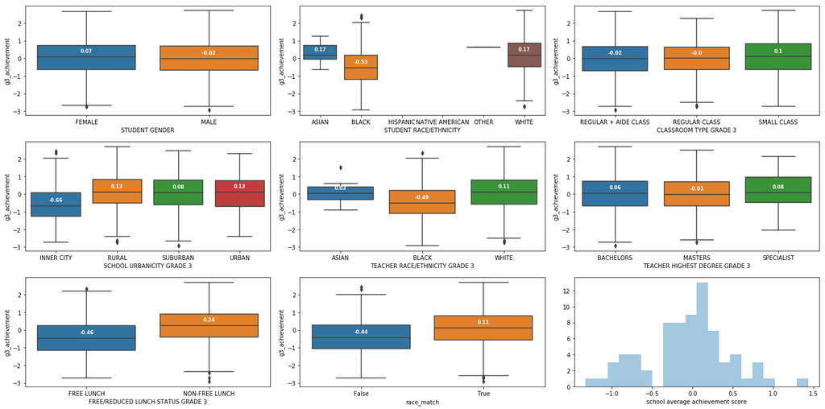

```python
#let's look at all of our categorical variables, and see how they split on achievement being above/below 0 ↔
```

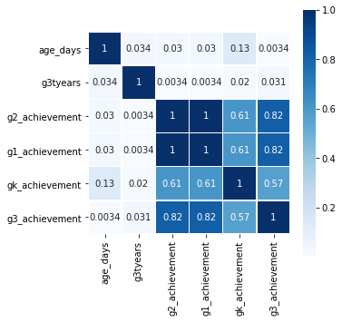

```python
#let's check out the correlation matrix with all of the continuous variables↔
```

### Model build and feature selection

Model types explored:

- tree-based ensemble: gradient booster, random forest
- linear regression: lasso, ridge and elasticnet models.

The modeling process proceeded in two steps:

- fit and tune the models, using random and grid-search methods, using the initial set of features.
- re-tune the models with a more limited set of features - the most important features identified in the first attempt

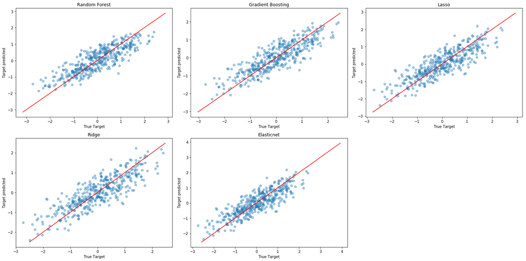

|  | best_alpha | r_squared_train | r_squared_test | mean_abs_err | mean_sq_err | rt_mean_sq_err | mean_abs_perc_err |
| --- | --- | --- | --- | --- | --- | --- | --- |
| Random Forest | NaN | 1.000000 | 0.713668 | 0.425643 | 0.277879 | 0.527143 | 132.174474 |
| Gradient Boosting | NaN | 0.849073 | 0.734365 | 0.410437 | 0.257793 | 0.507733 | 124.227017 |
| Lasso | 0.0001 | 0.751006 | 0.722670 | 0.415143 | 0.269143 | 0.518790 | 118.773618 |
| Ridge | 0.0100 | 0.753532 | 0.717352 | 0.418075 | 0.274304 | 0.523740 | 116.961339 |
| Elasticnet | 0.0001 | 0.751006 | 0.722670 | 0.415143 | 0.269143 | 0.518790 | 118.773618 |

```python
#fit random forest, gradient boosting, and regression models. ↔
```

|  | best_alpha | r_squared_train | r_squared_test | mean_abs_err | mean_sq_err | rt_mean_sq_err | mean_abs_perc_err |
| --- | --- | --- | --- | --- | --- | --- | --- |
| Random Forest | NaN | 1.000000 | 0.711942 | 0.426481 | 0.279554 | 0.528729 | 134.355343 |
| Gradient Boosting | NaN | 0.848300 | 0.728042 | 0.415221 | 0.263929 | 0.513741 | 127.470506 |
| Lasso | 0.00001 | 0.751843 | 0.715787 | 0.419911 | 0.275823 | 0.525189 | 120.088678 |
| Ridge | 0.00100 | 0.751907 | 0.715169 | 0.420436 | 0.276423 | 0.525760 | 120.020348 |
| Elasticnet | 0.00001 | 0.751843 | 0.715787 | 0.419911 | 0.275823 | 0.525189 | 120.088678 |

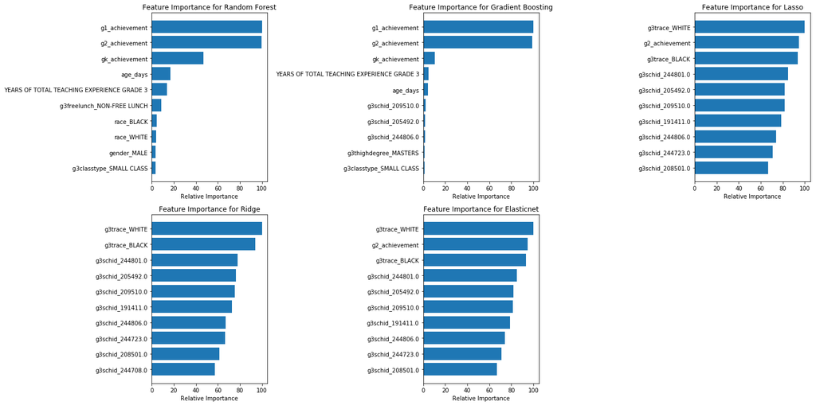

```python
#refit the models with just those features that were important in the first attempt - graph feature importance↔
```

```
The small class outperforms regular size and regular size with aid (p = 0.013 and 0.008 respectively)
There is not a significant difference in achievement between regular and regular with aid (p = 0.937)
```

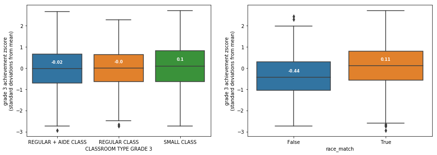

```
Students with same-race teacherss out-achieved those with different race teachers (p = 5.408921790865724e-16)
```

```python
#Size and statistical significance of class size and race-match on same-year achievement↔
```